# Data visualization

## Fundamentals and python tools

## what we will do:

- Talk about *what makes* a figure good in general.
- Basic plot types, and how to represent types of data.
- Plotting with Matplotlib, Seaborn and Pandas

[figure not shown]

G. Alain, Y. Bengio. *Understanding intermediate layers using linear classifier probes*. 2016

# 10 Rules for better figures

[source](http://journals.plos.org/ploscompbiol/article/file?id=10.1371/journal.pcbi.1003833&type=printable)

### 1. Know Your Audience

Is the figure for your exploratory data analysis?

or is it for a scientific publication?

### 2. Identify your message

How can the figure express the message you want to send to your audience

### 3. Adapt the Figure to the Support Medium

High detail for screens or papers

Low detail, bigger annotations for presentation

### 4. Captions Are Not Optional

Always describe the figure

### 5. Do Not Trust the Defaults

[example](https://github.com/rougier/matplotlib-tutorial)

### 6. Use Color Effectively

We will talk about this later!

### 7. Do Not Mislead the Reader

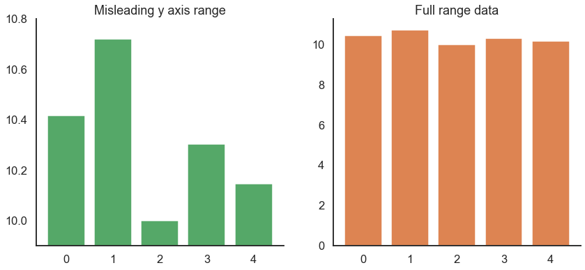

### 8. Avoid ‘‘Chartjunk’’

Avoid using to many colors

Visual elements that don't improve the message

### 9. Message Trumps Beauty

[see this](https://github.com/rougier/ten-rules/blob/master/figure-8.py)

### 10. Get the Right Tool

Matplotlib, seaborn, R, **ggplot**, Bokeh, plotly, D3js...

But always use tools that generate reproducible figures.

# Choose the right color palette

Color maps are build sampling from the color space.

For quantitative data:

- The color map must be **perceptually uniform** (colors that represent low values must be percieved darker than the colors for higher values).
- The **perceptual brightness** of the color must increase in a **continuous uniform way**.

## Color palettes:

Color is more important than other aspects of figure style because color can reveal patterns in the data if used effectively or hide those patterns if used poorly.

### Qualitative color palettes

Distinguish discrete chunks of data that do not have an inherent ordering.

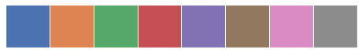

Circular color space:

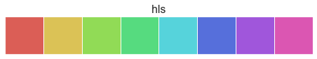

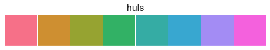

### Sequential color palettes

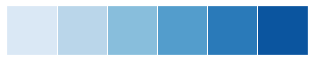

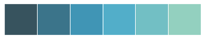

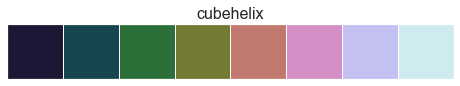

#### Perceptually uniform sequential color maps

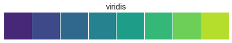

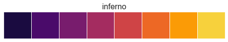

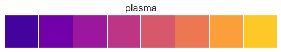

[Presentation at Scipy 2015](https://www.youtube.com/watch?v=xAoljeRJ3lU)

### Diverging color palettes

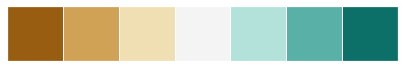

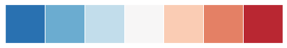

## The bad and ugly

for example, let's take a look at the following picture made with the color map **Jet**.

How is the data represented in the following picture. Does it have any gaps? or is it smooth?

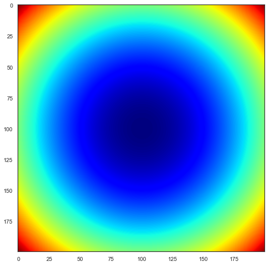

Let's look at the profile:

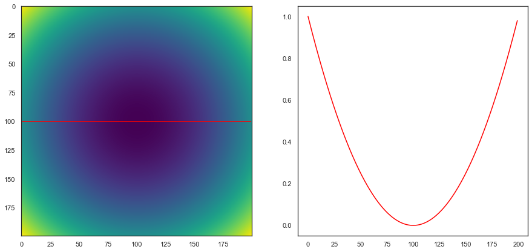

### Find the gap!

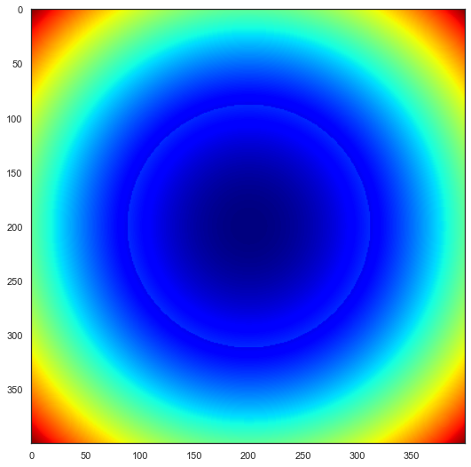

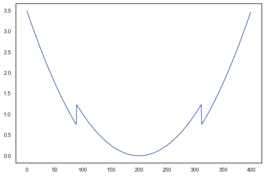

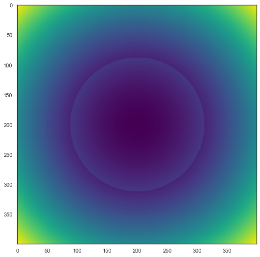

# Fast tour: basic visualizations

More in [Python Graph Gallery](https://python-graph-gallery.com/)

## Lines

A line chart is used to visualize a trend in data over intervals of time or points that have some kind of order.

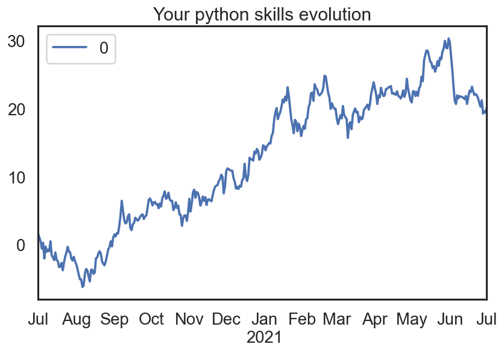

Or filled with area:

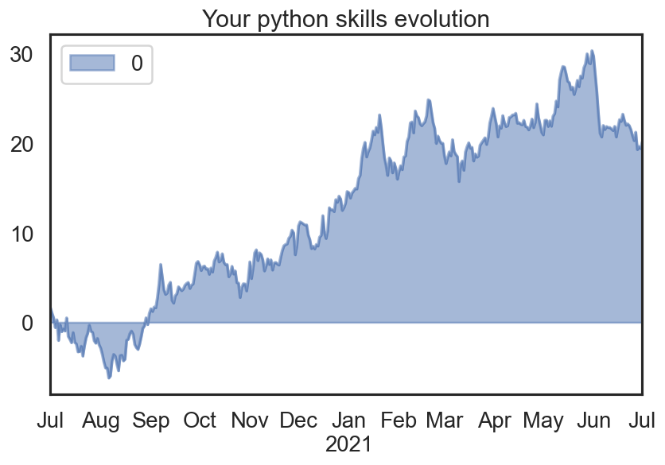

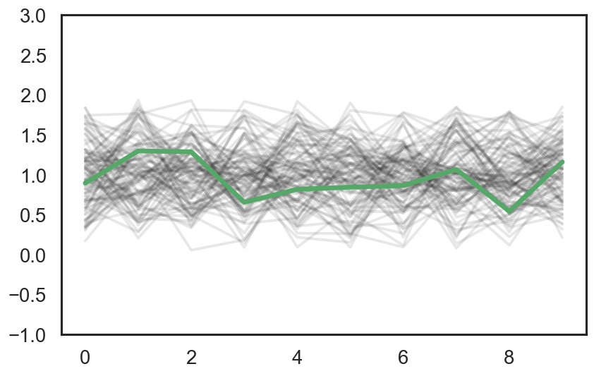

## Scatter

Used when we want to show relationship between two variables (correlation). Scatters are usefull and can encode up to 4 features.

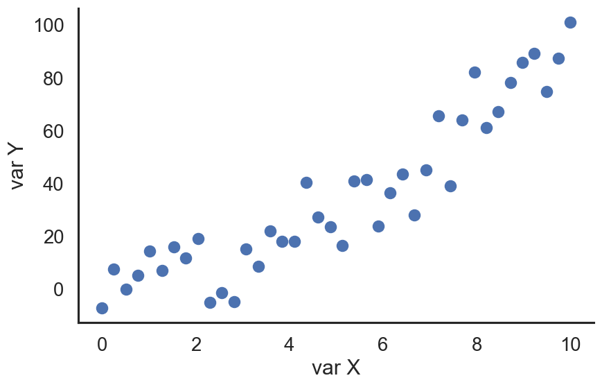

We can add more visual attributes to the scatter plot to represent more dimensions (aka bubble chart):

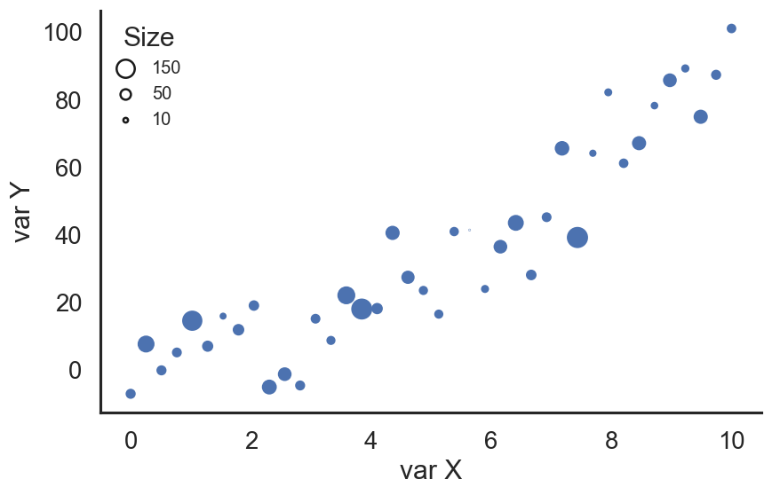

an even more with color:

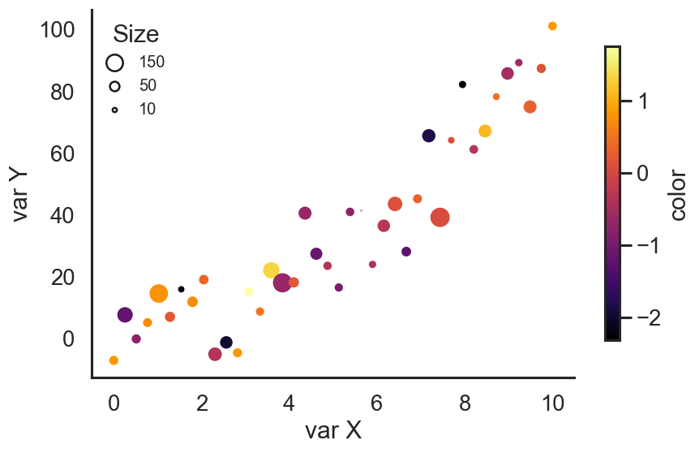

### Or compare the distribution of different classes

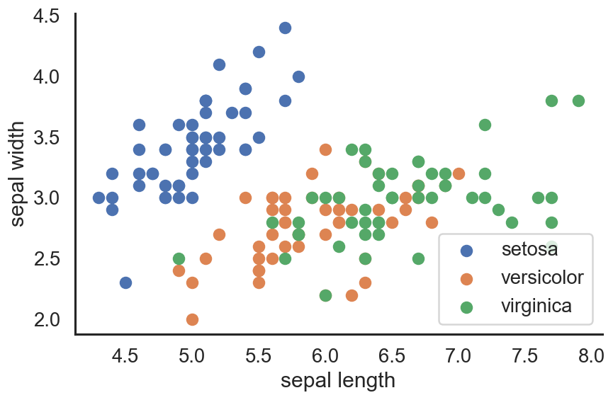

## Bar plots

It shows the relationship between a numerical variable and a categorical variable.

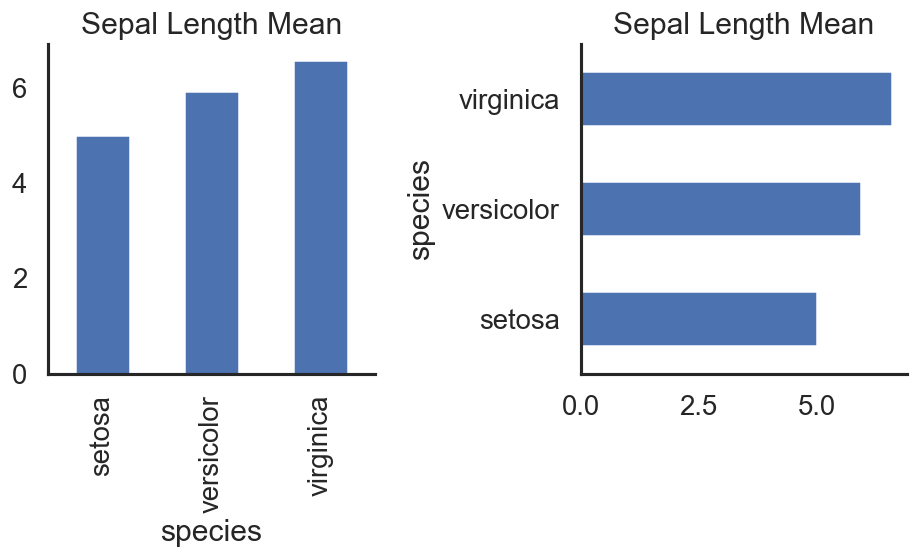

#### Multi-set Bar Chart:

It displays a numerical value for several entities, organized into groups and subgroups.

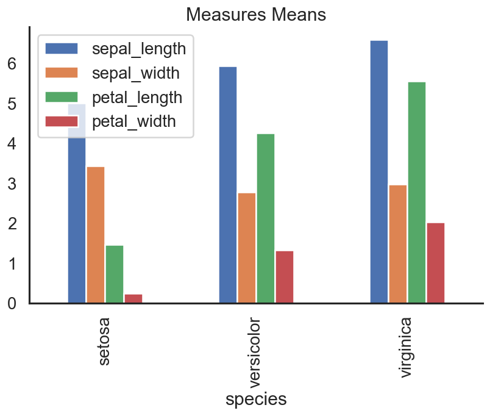

Stacked bars:

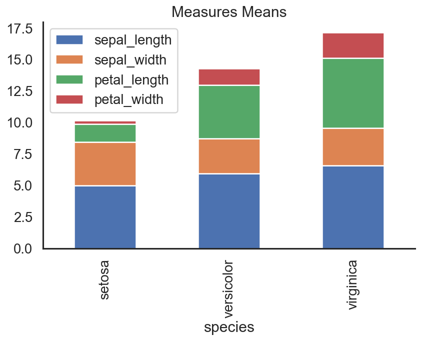

## Distribution

Used to visualize or get insights of the underlying distribution of the data.

### Histogram

An histogram is an *accurate* graphical representation of the distribution of numerical data.

But you have to be carefull with the number of bins.

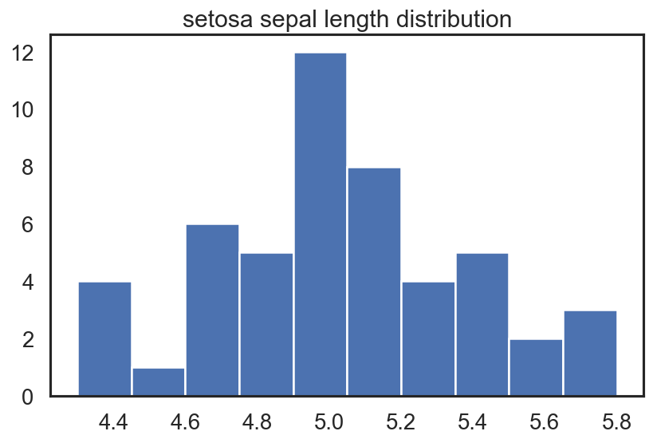

### Density plot

Shows the distribution (pmf) of a numerical variable.

The distribution is aproximated with the **KDE** (Kernel Density Stimation) algorithm.

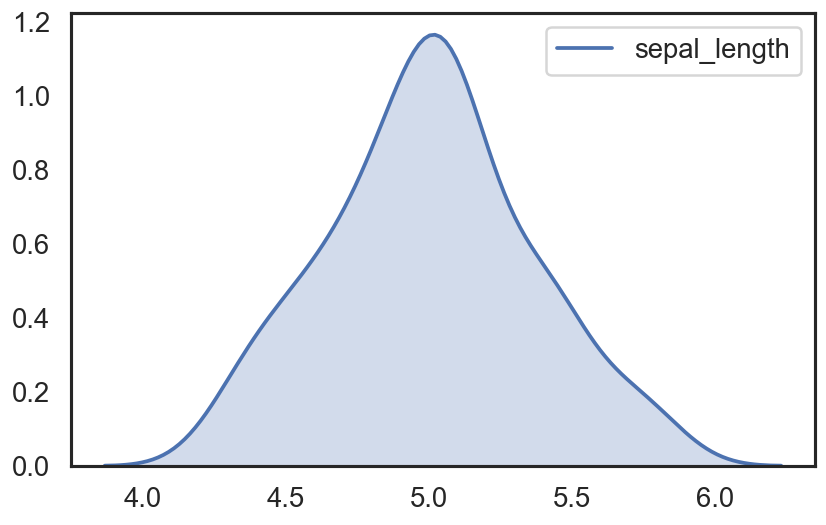

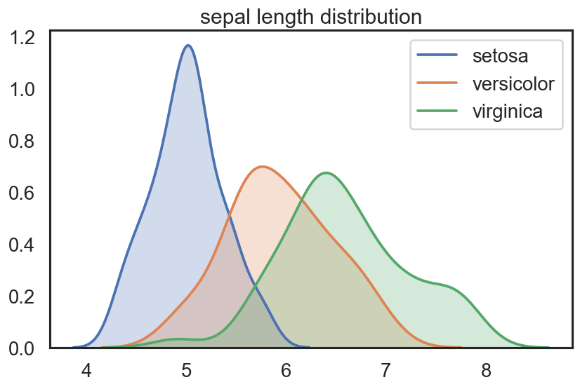